# Fertility and Wealth: Causal Evidence for Latin America

Work in progress

Edison Choque Sanchez

21/07/2022

# 1. Introduction

In this file we show the process to estimate the causal effect from fertility to household wealth. This process has three stages. First, we import the data base and explore it, but also we generate a subset of the data base because women are the group of analysis. Second, all the variable of interest should be created. For instance most of them should be transformed into the correct format. Finally, we show the result according to the model.

# 2. DHS program data

DHS surveys collect primary data using several types of questionnaires. A household questionnaire is used to collect information on characteristics of the household’s dwelling unit, and data related to the height and weight for women and children in the household. It is also used to identify members of the household who are eligible for an individual interview. Eligible respondents are then interviewed using an individual questionnaire.

In a majority of DHS surveys eligible individuals include women of reproductive age (15-49) and men age 15-59, or in some cases 15-54. In some countries only women are interviewed. Individual questionnaires include information on fertility, family planning and maternal and child health.

We use the individual record data. It mean that all women between 15 - 49 years old were interviewed. You can visit the following website to know about DHS program and data. [DHS program](https://dhsprogram.com/data/Getting-Started.cfm)

## Import data

We develop two econometric models. Both are causal models to measure raising children’s impact on household wealth.

To know the definition for the most of the variables, we suggest downloading the pdf files from the following link: [Files](https://dhsprogram.com/publications/publication-dhsg4-dhs-questionnaires-and-manuals.cfm). Once you enter to the link, download two pdf files: DHS-V Recode Manual and DHS-V Recode Map. In both, you can find more information about the variables and data structure.

The first econometric model considers the “infertility shock” as the instrument. The second one uses the “twins” variable as an alternative instrument. Most of them are changed to the correct format. We use both the **base_ir1** and **base_ir2** for the first and second econometric models respectively

This presentation keep on with the third section that shows the description of the variables. The fourth section explains a multiple correspondence analysis. We explain the principal results of the econometrics models in the fifth section. Finally, we present the principal conclusion and recommendations.

# 3. Description of the Database

## Model 1: Infertility shock

First, we explore the dependent variable which is the Wealth index factor score

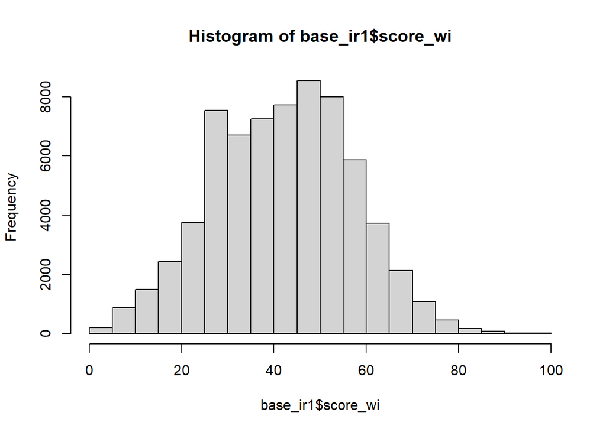

```r
hist(base_ir1$score_wi)
```

```r
summary(base_ir1$score_wi)
```

```
##    Min. 1st Qu.  Median    Mean 3rd Qu.    Max.
##    0.00   30.52   42.48   41.96   52.70  100.00
```

Second, we describe the endogenous variable that is fertility, which is the number of living children. But also, we can define this variable in different ways. See some of these options:

```r
table(base_ir1$children_home) # Number of children living at home
```

```
##
##     0     1     2     3     4     5     6     7     8     9    10    11    12
##  8290 14891 18290 13364  6742  3467  1679   796   356   128    48    15     4
##    13
##     1
```

```r
table(base_ir1$living_children) # Number of living children
```

```
##
##     0     1     2     3     4     5     6     7     8     9    10    11    12
##  4786 10699 15816 14968  8904  5249  3201  1934  1227   647   351   187    67
##    13    14    15    16    18
##    19     9     5     1     1
```

```r
table(base_ir1$v137) #v137 -Number of children 5 and under
```

```
##
##     0     1     2     3     4     5     6     7     8
## 31948 23207 10121  2445   286    55     6     2     1
```

```r
table(base_ir1$v219) # v219 -Living children + current preg
```

```
##
##     0     1     2     3     4     5     6     7     8     9    10    11    12
##  4008 10533 15956 15283  9128  5342  3254  1970  1254   682   360   194    72
##    13    14    15    16    18
##    19     9     4     2     1
```

Third, we describe the instrument for the endogenous variable. This instrument is defined in two ways. Both are self-declarations of infertility for women.

1. when the question is: Main reason not to use meth, and the answer is Subfecund, infecund.
2. when the question is: Fertility preference, and the answer is: Declared infecund.

According to these results, on average the number of living children in the infertile group is lower than the fertile group, so that makes sense.

```r
base_ir1 %>% group_by(infertility1) %>%  summarise(mean = mean(living_children), n = n())
```

```
## # A tibble: 2 × 3
##   infertility1  mean     n
##          <dbl> <dbl> <int>
## 1            0  3.00 66426
## 2            1  2.88  1645
```

```r
base_ir1 %>% group_by(infertility2) %>%  summarise(mean = mean(living_children), n = n())
```

```
## # A tibble: 2 × 3
##   infertility2  mean     n
##          <dbl> <dbl> <int>
## 1            0  3.00 66119
## 2            1  2.90  1952
```

```r
base_ir1 %>% group_by(instrument) %>%  summarise(mean = mean(living_children), n = n()) #instrument is defined as infertility1 or  infertility2
```

```
## # A tibble: 2 × 3
##   instrument  mean     n
##        <dbl> <dbl> <int>
## 1          0  3.01 65793
## 2          1  2.78  2278
```

Finally, we describe the rest of the variables for model 1.

```r
summary(base_ir1$v012) #V012 - Current age - respondent
```

```
##    Min. 1st Qu.  Median    Mean 3rd Qu.    Max.
##   13.00   27.00   35.00   34.34   41.00   49.00
```

```r
summary(base_ir1$v212) # v212 Age of respondent at 1st birth
```

```
##    Min. 1st Qu.  Median    Mean 3rd Qu.    Max.    NA's
##    9.00   17.00   19.00   19.99   22.00   46.00    4541
```

```r
summary(base_ir1$v133) # v133 - Education in single years
```

```
##    Min. 1st Qu.  Median    Mean 3rd Qu.    Max.
##   0.000   3.000   6.000   7.066  11.000  99.000
```

```r
table(base_ir1$urban) # v025 - Type of place of residence
```

```
##
##     0     1
## 28391 39680
```

### Model 2: Twins

Now we can describe the instrumental variable for model 2. This is defined as *twin*. We assume that mothers with the experience of having twins have to raise extra children. That is why it works as a good instrument to measure the causal effect.

In the next chunk, we show a summary table for the mean of the number of children living at home according to mothers who had twins and the ones that did not. The result shows that this mean is lower for the mothers who never had twins than the ones who did, so that makes sense.

```r
base_ir2 %>% group_by(twin) %>%  summarise(mean = mean(children_home), n = n())
```

```
## # A tibble: 2 × 3
##    twin  mean     n
##   <dbl> <dbl> <int>
## 1     0  2.58 57993
## 2     1  3.75  1788
```

Finally, we present the description for the rest of the variables for model 2.

```r
summary(base_ir2$max_agechildren) # Maximun age of the children at home
```

```
##    Min. 1st Qu.  Median    Mean 3rd Qu.    Max.
##    0.00    7.00   14.00   13.95   20.00   39.00
```

```r
summary(base_ir2$v012) #V012 - Current age - respondent
```

```
##    Min. 1st Qu.  Median    Mean 3rd Qu.    Max.
##   14.00   28.00   35.00   34.64   41.00   49.00
```

```r
summary(base_ir2$v212) # v212 Age of respondent at 1st birth
```

```
##    Min. 1st Qu.  Median    Mean 3rd Qu.    Max.
##    9.00   17.00   19.00   20.05   22.00   46.00
```

```r
summary(base_ir2$v133) # v133 - Education in single years
```

```
##    Min. 1st Qu.  Median    Mean 3rd Qu.    Max.
##   0.000   3.000   6.000   6.888  11.000  99.000
```

```r
table(base_ir2$urban) # 1 urbano - 0 rural
```

```
##
##     0     1
## 25487 34294
```

# 4. Multiple Correpondence Analysis

This section shows the application of Multiple Correspondence Analysis (MCA) to know the relationship among five categorical variables. These variables are: children_cat, wealth index, residence (rural or urban), country and education level.

Here a breave description of this variables:

```r
#Data base generation
vv <- names(base_ir1)[c(66,30,64, 2, 9)]
t2 <- base_ir1 %>% select(all_of(vv))
table(t2$children_categ)
```

```
##
##     0     1     2     3     4     5
##  4786 10699 15816 14968  8904 12898
```

```r
table(t2$v190) # wealth index
```

```
##
##     1     2     3     4     5
## 15525 15584 14286 12671 10005
```

```r
table(t2$urban)
```

```
##
##     0     1
## 28391 39680
```

```r
table(t2$v000)
```

```
##
##   BO5   CO4   DR5   GY5   HN5   HT5
## 10573 21556 16758  2945 11124  5115
```

```r
table(t2$v106) #education level
```

```
##
##     0     1     2     3
##  6045 31524 22333  8169
```

To make a graph analysis, we use the FactoMineR library in R created by Husson, F., Le, S. and Pages, J. (2010). Before to present the graph, it is important to add labels to the data *t2* as follows:

```r
#add labels to data
t2$children_categ[t2$children_categ==0]="no children"
t2$children_categ[t2$children_categ==1]="1 child"
t2$children_categ[t2$children_categ==2]="2 children"
t2$children_categ[t2$children_categ==3]="3 children"
t2$children_categ[t2$children_categ==4]="4 children"
t2$children_categ[t2$children_categ==5]="more 5 children"

t2$v190[t2$v190==1]="Poorest"
t2$v190[t2$v190==2]="Poorer"
t2$v190[t2$v190==3]="Middle"
t2$v190[t2$v190==4]="Richer"
t2$v190[t2$v190==5]="Richest"

t2$urban[t2$urban==1]="urbano"
t2$urban[t2$urban==0]="rural"

t2$v106[t2$v106==0]="No education"
t2$v106[t2$v106==1]="Primary"
t2$v106[t2$v106==2]="Secondary"
t2$v106[t2$v106==3]="Higher"
```

Now, we can show the principal graph to study the MCA.

```r
model_mca <- MCA(t2[,c("children_categ", "v190", "urban", "v000", "v106")])
```

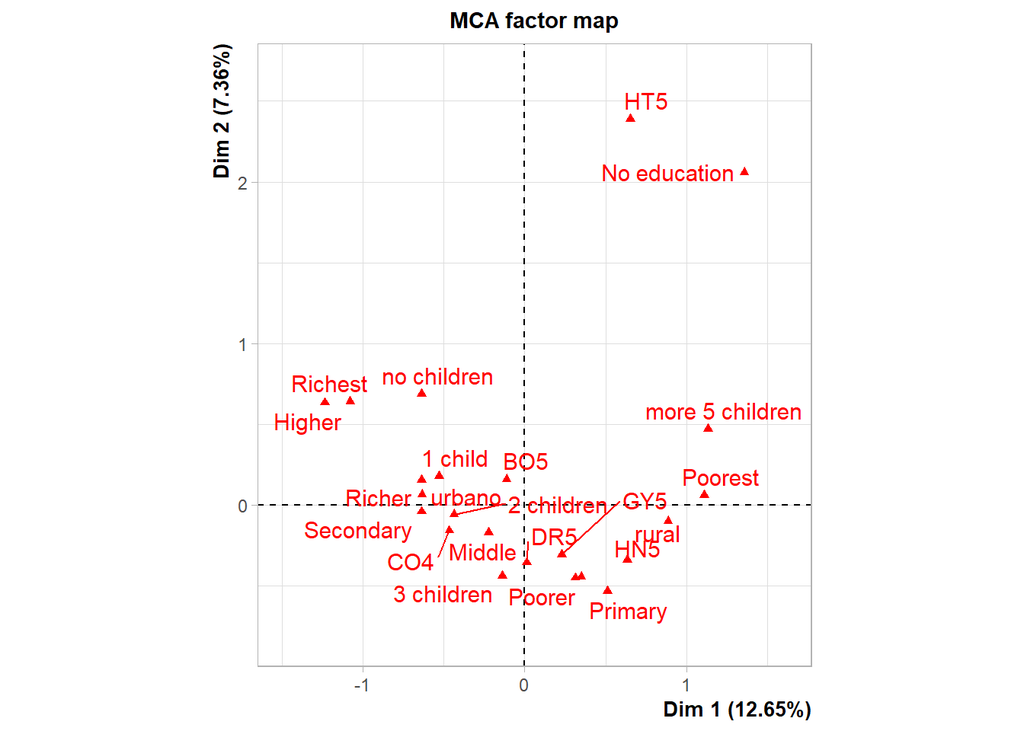

[figure not shown]

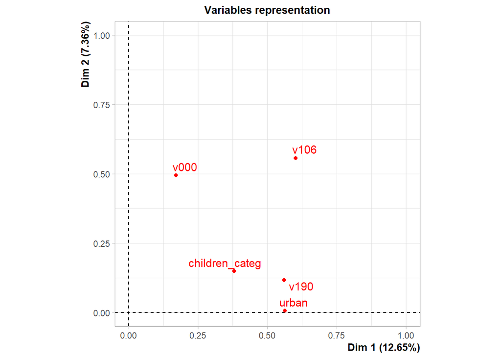

The graph should be interpreted according to the punctuated axes. It can be interpreted in two ways. First, if two o more variables are close, it means that a correlation. Second, if this variables are far from the origin, we can assume a strong correlation.

As we can see, the is a strong correlation between Richest people and Higher education. We can see that it is also close to the category *no children*. Also, the category of richest is correlated with the category of *1 child and urbano*. .

if we see countries, the is a correlation between *Haiti and women with no education*. Also, we can see *poorer people and primary education*.

# 5. Econometrics Models

## Model 1: Infertility shock

Definition of the dependent variables:

- score_wi: Wealth index factor score standardized

Definition of the endogenous variables:

- living_children: number of living children

The covariates were defined as follow:

- V012: Current age - respondent
- v212: Age of respondent at 1st birth
- v133: Education in single years
- urban: the responded live in urban area

```r
model_a1 <- lm(score_wi ~ living_children + v012 + v133 + v212 + urban, data = base_ir1)
summary(model_a1)
```

```
##
## Call:
## lm(formula = score_wi ~ living_children + v012 + v133 + v212 +
##     urban, data = base_ir1)
##
## Residuals:
##      Min       1Q   Median       3Q      Max
## -105.779   -6.650    0.116    6.670   64.796
##
## Coefficients:
##                  Estimate Std. Error t value Pr(>|t|)
## (Intercept)     20.064249   0.265578  75.549  < 2e-16 ***
## living_children -1.542415   0.029118 -52.972  < 2e-16 ***
## v012             0.405251   0.006452  62.807  < 2e-16 ***
## v133             0.903697   0.009768  92.515  < 2e-16 ***
## v212            -0.050913   0.012281  -4.146 3.39e-05 ***
## urban           12.627019   0.094528 133.579  < 2e-16 ***
## ---
## Signif. codes:  0 '***' 0.001 '**' 0.01 '*' 0.05 '.' 0.1 ' ' 1
##
## Residual standard error: 10.86 on 63524 degrees of freedom
##   (4541 observations deleted due to missingness)
## Multiple R-squared:  0.4764, Adjusted R-squared:  0.4763
## F-statistic: 1.156e+04 on 5 and 63524 DF,  p-value: < 2.2e-16
```

```r
confint(model_a1)
```

```
##                       2.5 %      97.5 %
## (Intercept)     19.54371585 20.58478294
## living_children -1.59948599 -1.48534478
## v012             0.39260418  0.41789732
## v133             0.88455147  0.92284259
## v212            -0.07498447 -0.02684147
## urban           12.44174294 12.81229490
```

For the model_a1, we do not consider any instrument, so it will be useful to compare these results with the model_a2 and model_a3 that apply the infertility instrument.

```r
model_a2 <- tsls(score_wi~ living_children + v012 + v133 + v212 + urban,
                 ~ instrument + v012 + v133 + v212 + urban, data = base_ir1)
summary(model_a2)
```

```
##
##  2SLS Estimates
##
## Model Formula: score_wi ~ living_children + v012 + v133 + v212 + urban
##
## Instruments: ~instrument + v012 + v133 + v212 + urban
##
## Residuals:
##       Min.    1st Qu.     Median       Mean    3rd Qu.       Max.
## -111.96094   -6.63474    0.03372    0.00000    6.68051   66.21182
##
##                    Estimate  Std. Error  t value   Pr(>|t|)
## (Intercept)     16.36230579  1.08764176 15.04384 < 2.22e-16 ***
## living_children -0.35266903  0.33996975 -1.03735   0.299575
## v012             0.26380779  0.04079199  6.46715 1.0059e-10 ***
## v133             0.98531703  0.02525444 39.01560 < 2.22e-16 ***
## v212             0.14031809  0.05584182  2.51278   0.011981 *
## urban           13.36536179  0.23097291 57.86549 < 2.22e-16 ***
## ---
## Signif. codes:  0 '***' 0.001 '**' 0.01 '*' 0.05 '.' 0.1 ' ' 1
##
## Residual standard error: 11.0013041 on 63524 degrees of freedom
```

```r
confint(model_a2)
```

```
##                       2.5 %     97.5 %
## (Intercept)     14.23056712 18.4940445
## living_children -1.01899750  0.3136594
## v012             0.18385696  0.3437586
## v133             0.93581924  1.0348148
## v212             0.03087014  0.2497660
## urban           12.91266320 13.8180604
```

```r
model_a3 <- tsls(score_wi~ living_children + v012 + v133 + v212,
                 ~ instrument + v012 + v133 + v212, data = base_ir1)
summary(model_a3)
```

```
##
##  2SLS Estimates
##
## Model Formula: score_wi ~ living_children + v012 + v133 + v212
##
## Instruments: ~instrument + v012 + v133 + v212
##
## Residuals:
##      Min.   1st Qu.    Median      Mean   3rd Qu.      Max.
## -155.3664   -7.7517    0.2072    0.0000    8.2730   57.5070
##
##                    Estimate  Std. Error  t value Pr(>|t|)
## (Intercept)     20.10575914  1.16828445 17.20964  < 2e-16 ***
## living_children -0.86395939  0.37640722 -2.29528 0.021720 *
## v012             0.36724047  0.04442689  8.26617  < 2e-16 ***
## v133             1.37678040  0.03504304 39.28827  < 2e-16 ***
## v212             0.10419652  0.06269641  1.66192 0.096533 .
## ---
## Signif. codes:  0 '***' 0.001 '**' 0.01 '*' 0.05 '.' 0.1 ' ' 1
##
## Residual standard error: 12.4758774 on 63525 degrees of freedom
```

```r
confint(model_a3)
```

```
##                       2.5 %     97.5 %
## (Intercept)     17.81596369 22.3955546
## living_children -1.60170398 -0.1262148
## v012             0.28016536  0.4543156
## v133             1.30809731  1.4454635
## v212            -0.01868619  0.2270792
```

The principal results show that the causal effect from fertility to the score of wealth index in negative for the model_a3, and it is statistically significant. It is important to notice that the causal effect from the *living_children* variable is small in average for each children. And also, notice that is we control by *urban* variable, the causal effect is not statistically significant (see model_2a).

## Model 2: Twins

Definition of the dependent variables:

- score_wi: Wealth index factor score standardized

Definition of the endogenous variables:

- children_home: number of children living at home

The covariates were defined as follow:

- V012: Current age - respondent
- v212: Age of respondent at 1st birth
- v133: Education in single years
- urban: the responded live in urban area

```r
model_b1 <- lm(score_wi ~ children_home + v012 + v133 + v212 + urban,
               data = base_ir2)
summary(model_b1)
```

```
##
## Call:
## lm(formula = score_wi ~ children_home + v012 + v133 + v212 +
##     urban, data = base_ir2)
##
## Residuals:
##      Min       1Q   Median       3Q      Max
## -110.963   -6.647    0.079    6.691   65.255
##
## Coefficients:
##                Estimate Std. Error t value Pr(>|t|)
## (Intercept)   18.311731   0.275436  66.483   <2e-16 ***
## children_home -1.143502   0.032878 -34.781   <2e-16 ***
## v012           0.281047   0.005988  46.933   <2e-16 ***
## v133           0.963772   0.010113  95.298   <2e-16 ***
## v212           0.119856   0.012079   9.922   <2e-16 ***
## urban         13.233247   0.097922 135.140   <2e-16 ***
## ---
## Signif. codes:  0 '***' 0.001 '**' 0.01 '*' 0.05 '.' 0.1 ' ' 1
##
## Residual standard error: 10.97 on 59775 degrees of freedom
## Multiple R-squared:  0.4719, Adjusted R-squared:  0.4718
## F-statistic: 1.068e+04 on 5 and 59775 DF,  p-value: < 2.2e-16
```

```r
confint(model_b1)
```

```
##                     2.5 %     97.5 %
## (Intercept)   17.77187515 18.8515873
## children_home -1.20794242 -1.0790617
## v012           0.26931044  0.2927844
## v133           0.94394973  0.9835937
## v212           0.09617981  0.1435315
## urban         13.04131884 13.4251747
```

For the model_b1, we do not consider any instrument, so it will be useful to compare these results with the model_b2 and model_b3 that apply the twin instrument.

```r
model_b2 <- tsls(score_wi~ children_home + v012 + v133 + v212  + urban,
                 ~ twin + v012 + v133 + v212  + urban , data = base_ir2)
summary(model_b2)
```

```
##
##  2SLS Estimates
##
## Model Formula: score_wi ~ children_home + v012 + v133 + v212 + urban
##
## Instruments: ~twin + v012 + v133 + v212 + urban
##
## Residuals:
##      Min.   1st Qu.    Median      Mean   3rd Qu.      Max.
## -109.3407   -6.6931    0.1109    0.0000    6.7348   64.6102
##
##                  Estimate  Std. Error  t value   Pr(>|t|)
## (Intercept)   19.78401018  0.90267363 21.91712 < 2.22e-16 ***
## children_home -1.65911908  0.30278917 -5.47945 4.2836e-08 ***
## v012           0.30655771  0.01605513 19.09406 < 2.22e-16 ***
## v133           0.93898730  0.01766406 53.15805 < 2.22e-16 ***
## v212           0.08454855  0.02390207  3.53729 0.00040456 ***
## urban         13.00662558  0.16470854 78.96752 < 2.22e-16 ***
## ---
## Signif. codes:  0 '***' 0.001 '**' 0.01 '*' 0.05 '.' 0.1 ' ' 1
##
## Residual standard error: 10.9892278 on 59775 degrees of freedom
```

```r
confint(model_b2)
```

```
##                     2.5 %     97.5 %
## (Intercept)   18.01480238 21.5532180
## children_home -2.25257494 -1.0656632
## v012           0.27509023  0.3380252
## v133           0.90436637  0.9736082
## v212           0.03770135  0.1313957
## urban         12.68380277 13.3294484
```

```r
model_b3 <- tsls(score_wi~ children_home + v012 + v212,
                 ~ twin + v012 + v212 , data = base_ir2)
summary(model_b3)
```

```
##
##  2SLS Estimates
##
## Model Formula: score_wi ~ children_home + v012 + v212
##
## Instruments: ~twin + v012 + v212
##
## Residuals:
##     Min.  1st Qu.   Median     Mean  3rd Qu.     Max.
## -51.0084  -9.5402   0.3684   0.0000   9.7556  58.1074
##
##                  Estimate  Std. Error   t value   Pr(>|t|)
## (Intercept)   30.56416320  0.99346714  30.76515 < 2.22e-16 ***
## children_home -3.80659689  0.35404224 -10.75182 < 2.22e-16 ***
## v012           0.32680414  0.02061491  15.85281 < 2.22e-16 ***
## v212           0.48659847  0.03682837  13.21260 < 2.22e-16 ***
## ---
## Signif. codes:  0 '***' 0.001 '**' 0.01 '*' 0.05 '.' 0.1 ' ' 1
##
## Residual standard error: 14.1119191 on 59777 degrees of freedom
```

```r
confint(model_b3)
```

```
##                    2.5 %     97.5 %
## (Intercept)   28.6170034 32.5113230
## children_home -4.5005069 -3.1126868
## v012           0.2863997  0.3672086
## v212           0.4144162  0.5587807
```

# 5. Discussion and recomendations

- Check if the results change if we use individual survey weight
- We should consider the tests for weak instrument (we develop this test in Stata)
- We should consider the test for the external validation like Hansen test
- We can use a restriction for the maximum age of the children living at home.